# R-Prep-Answers

Tallulah Story

2026-07-24

# R Preparedness

This assignment is due August 27th. In order to receive full credit students should:

1. Follow Tutorial 1 from start to finish.
2. Complete the Questions as they go.
3. Type their answers into the provided code chunks below or in the text space provided.
4. Ask questions if they arise.

## Question 1

**1a. Get and set your working directory based on the suggested file path in Tutorial 0.**

**1b. Install the Palmer penguins data set onto your computer using the console. Load the data set into your working script.**

**1c. Import the tidepool metadata practice data set and save it as “data”.**

```r
getwd()
```

```
## [1] "/Users/loganstory/Desktop/PhD/Teaching/R Bootcamp/R-bootcamp"
```

```r
setwd("/Users/loganstory/Desktop/PhD/Teaching/R Bootcamp/R-bootcamp") # should be students wd

library(palmerpenguins)
# data should have a descrptive data frame object name later down the line, but saved as 'data' for now
data <- read.csv("metadata_tidepool.csv")
```

## Question 2

**2a. Retrieve the summary, head, and tail of the tide pool metadata set**.

```r
summary(data)
```

```
##   Pool_number        Volume            TidePoolSize macro_Shannon_sessile
##  Min.   : 1.00   Min.   :0.009257   Length   :12    Min.   :0.6660
##  1st Qu.: 3.75   1st Qu.:0.116605   N.unique : 2    1st Qu.:0.8379
##  Median : 6.50   Median :0.534322   N.blank  : 0    Median :1.0079
##  Mean   : 6.50   Mean   :1.793610   Min.nchar: 5    Mean   :1.2106
##  3rd Qu.: 9.25   3rd Qu.:1.949672   Max.nchar: 5    3rd Qu.:1.5720
##  Max.   :12.00   Max.   :8.326980                   Max.   :2.0856
##  macro_Shannon_mobile macro_Shannon_mean macro_Richness   macro_Autotroph
##  Min.   :0.4349       Min.   :0.5505     Min.   : 5.000   Min.   :13.90
##  1st Qu.:0.5596       1st Qu.:0.7301     1st Qu.: 7.000   1st Qu.:15.14
##  Median :0.6338       Median :0.9692     Median : 8.500   Median :18.44
##  Mean   :0.7243       Mean   :0.9674     Mean   : 8.833   Mean   :22.51
##  3rd Qu.:0.8665       3rd Qu.:1.1671     3rd Qu.:10.250   3rd Qu.:30.65
##  Max.   :1.2805       Max.   :1.4331     Max.   :15.000   Max.   :39.00
##  macro_Heterotroph
##  Min.   : 3.000
##  1st Qu.: 8.906
##  Median :13.292
##  Mean   :13.800
##  3rd Qu.:16.604
##  Max.   :31.071
```

```r
head(data)
```

```
##   Pool_number      Volume TidePoolSize macro_Shannon_sessile
## 1           1 8.326979824        large             0.8127783
## 2           2 0.009257226        small             0.6884039
## 3           3 1.403244719        large             1.7786047
## 4           4 0.089430671        small             0.9427402
## 5           5 0.125663706        small             1.5157038
## 6           6 1.120668931        large             0.9025872
##   macro_Shannon_mobile macro_Shannon_mean macro_Richness macro_Autotroph
## 1            0.5641681          0.6884732              7        32.61111
## 2            0.8544150          0.7714094              5        30.00000
## 3            0.5209896          1.1497972             10        19.88889
## 4            1.2805192          1.1116297             10        17.00000
## 5            0.9220194          1.2188616             11        14.80000
## 6            0.5457430          0.7241651              7        39.00000
##   macro_Heterotroph
## 1          13.41667
## 2           6.00000
## 3           3.00000
## 4           9.87500
## 5          19.16667
## 6          13.43333
```

```r
tail(data)
```

```
##    Pool_number     Volume TidePoolSize macro_Shannon_sessile
## 7            7 5.53622767        large             0.6659899
## 8            8 0.19603538        small             1.5363085
## 9            9 3.58895545        large             1.0730248
## 10          10 0.87260878        large             1.6790352
## 11          11 0.08595398        small             0.8462418
## 12          12 0.16828883        small             2.0855988
##    macro_Shannon_mobile macro_Shannon_mean macro_Richness macro_Autotroph
## 7             0.4349348          0.5504623              5        36.22222
## 8             0.6358088          1.0860586             12        14.00000
## 9             0.6317819          0.8524034              8        15.46667
## 10            0.9027238          1.2908795              9        22.00000
## 11            0.6179377          0.7320898              7        15.25000
## 12            0.7806459          1.4331224             15        13.90000
##    macro_Heterotroph
## 7          24.000000
## 8          31.071429
## 9           4.416667
## 10         15.750000
## 11         13.166667
## 12         12.300000
```

**2c. How many rows does the tidepool metadata set have?**

Answer: 12

## Question 3

**3a. What is the atomic data type of tide pool size? How many tide pool sizes are there?**

```r
class(data$TidePoolSize)
```

```
## [1] "character"
```

Answer: “Character”; A dichotomous categorical variable, including Large and Small tidepools

**3b. Rename the tidepool metadata object (if you haven’t already) using** `snake_case` **convention.**

```r
tide_pool_data <- read.csv("metadata_tidepool.csv") # new name should be descriptive and lowercase
```

**3c. Rename all variables in your new tide pool data frame to match** `snake_case` **conventions.**

```r
names(tide_pool_data) <- c("pool_number",             # all columns should be using all lowercase
                           "volume",
                           "tide_pool_size",
                           "macro_shannon_sessile",
                           "macro_shannon_mobile",
                           "macro_shannon_mean",
                           "macro_richness",
                           "macro_autotroph",
                           "macro_heterotroph")
```

## Question 4

**Use code to install the tidyverse and dplyr packages in the console; Load the packages into your working session.**

```r
library(tidyverse) # if this step is done consecutively, awesome! If not, no worries
library(dplyr)
```

**Note: This would normally be done at the beginning of any real working script. Ensure that all package installations take place before any commands are run. For the sake of our learning here, we’re installing it later into our script.

## Question 5

**5a. Filter the tide pool data to only include large tide pools with a macro richness that is >= to 7.**

```r
filter(tide_pool_data, tide_pool_size == "large" & macro_richness >= 7)
```

```
##   pool_number    volume tide_pool_size macro_shannon_sessile
## 1           1 8.3269798          large             0.8127783
## 2           3 1.4032447          large             1.7786047
## 3           6 1.1206689          large             0.9025872
## 4           9 3.5889554          large             1.0730248
## 5          10 0.8726088          large             1.6790352
##   macro_shannon_mobile macro_shannon_mean macro_richness macro_autotroph
## 1            0.5641681          0.6884732              7        32.61111
## 2            0.5209896          1.1497972             10        19.88889
## 3            0.5457430          0.7241651              7        39.00000
## 4            0.6317819          0.8524034              8        15.46667
## 5            0.9027238          1.2908795              9        22.00000
##   macro_heterotroph
## 1         13.416667
## 2          3.000000
## 3         13.433333
## 4          4.416667
## 5         15.750000
```

**5b. Filter the Palmer penguins data set to only include male penguins that were measured in every year except 2007 on Biscoe island (HINT: try using the ! logical operator to exclude 2007).**

```r
filter(penguins, !year %in% 2007 & sex == "male" & island == "Biscoe")
```

```
## # A tibble: 61 × 8
##    species island bill_length_mm bill_depth_mm flipper_length_mm body_mass_g
##    <fct>   <fct>           <dbl>         <dbl>             <int>       <int>
##  1 Adelie  Biscoe           40.1          18.9               188        4300
##  2 Adelie  Biscoe           42            19.5               200        4050
##  3 Adelie  Biscoe           41.4          18.6               191        3700
##  4 Adelie  Biscoe           40.6          18.8               193        3800
##  5 Adelie  Biscoe           37.6          19.1               194        3750
##  6 Adelie  Biscoe           41.3          21.1               195        4400
##  7 Adelie  Biscoe           41.1          18.2               192        4050
##  8 Adelie  Biscoe           41.6          18                 192        3950
##  9 Adelie  Biscoe           41.1          19.1               188        4100
## 10 Adelie  Biscoe           41            20                 203        4725
## # ℹ 51 more rows
## # ℹ 2 more variables: sex <fct>, year <int>
```

## Question 6

**6a. How could you use `arrange()` to sort all missing values to the start? Write a line of code that sorts the missing values (NAs) for sex in the penguins data set to the start. (HINT: try using `is.na()`).**

```r
arrange(penguins, desc(is.na(sex)))
```

```
## # A tibble: 344 × 8
##    species island    bill_length_mm bill_depth_mm flipper_length_mm body_mass_g
##    <fct>   <fct>              <dbl>         <dbl>             <int>       <int>
##  1 Adelie  Torgersen           NA            NA                  NA          NA
##  2 Adelie  Torgersen           34.1          18.1               193        3475
##  3 Adelie  Torgersen           42            20.2               190        4250
##  4 Adelie  Torgersen           37.8          17.1               186        3300
##  5 Adelie  Torgersen           37.8          17.3               180        3700
##  6 Adelie  Dream               37.5          18.9               179        2975
##  7 Gentoo  Biscoe              44.5          14.3               216        4100
##  8 Gentoo  Biscoe              46.2          14.4               214        4650
##  9 Gentoo  Biscoe              47.3          13.8               216        4725
## 10 Gentoo  Biscoe              44.5          15.7               217        4875
## # ℹ 334 more rows
## # ℹ 2 more variables: sex <fct>, year <int>
```

**6b. In the tide pool data frame, arrange the observations in descending order by the macro Shannon mean and the macro richness.**

```r
arrange(tide_pool_data, desc(macro_shannon_mean), desc(macro_richness))
```

```
##    pool_number      volume tide_pool_size macro_shannon_sessile
## 1           12 0.168288835          small             2.0855988
## 2           10 0.872608775          large             1.6790352
## 3            5 0.125663706          small             1.5157038
## 4            3 1.403244719          large             1.7786047
## 5            4 0.089430671          small             0.9427402
## 6            8 0.196035382          small             1.5363085
## 7            9 3.588955447          large             1.0730248
## 8            2 0.009257226          small             0.6884039
## 9           11 0.085953975          small             0.8462418
## 10           6 1.120668931          large             0.9025872
## 11           1 8.326979824          large             0.8127783
## 12           7 5.536227671          large             0.6659899
##    macro_shannon_mobile macro_shannon_mean macro_richness macro_autotroph
## 1             0.7806459          1.4331224             15        13.90000
```

[output cut: 24 more lines]

## Question 7

**7a. Create a sub-set of the tidepool data that only includes the pool number, Shannon’s diversity metrics for macro sessile and mobile organisms, and the macro richness.**

```r
(tide_pool_subset <- select(tide_pool_data,          # bonus if each line (yay tidy code practices!!)
                           pool_number,
                           macro_shannon_sessile,
                           macro_shannon_mobile,
                           macro_richness))
```

```
##    pool_number macro_shannon_sessile macro_shannon_mobile macro_richness
## 1            1             0.8127783            0.5641681              7
## 2            2             0.6884039            0.8544150              5
## 3            3             1.7786047            0.5209896             10
## 4            4             0.9427402            1.2805192             10
## 5            5             1.5157038            0.9220194             11
## 6            6             0.9025872            0.5457430              7
## 7            7             0.6659899            0.4349348              5
## 8            8             1.5363085            0.6358088             12
## 9            9             1.0730248            0.6317819              8
## 10          10             1.6790352            0.9027238              9
## 11          11             0.8462418            0.6179377              7
## 12          12             2.0855988            0.7806459             15
```

**7b. Arrange your new sub-set in descending order by the pool number.**

```r
arrange(tide_pool_subset, desc(pool_number))
```

```
##    pool_number macro_shannon_sessile macro_shannon_mobile macro_richness
## 1           12             2.0855988            0.7806459             15
## 2           11             0.8462418            0.6179377              7
## 3           10             1.6790352            0.9027238              9
## 4            9             1.0730248            0.6317819              8
## 5            8             1.5363085            0.6358088             12
## 6            7             0.6659899            0.4349348              5
## 7            6             0.9025872            0.5457430              7
## 8            5             1.5157038            0.9220194             11
## 9            4             0.9427402            1.2805192             10
## 10           3             1.7786047            0.5209896             10
## 11           2             0.6884039            0.8544150              5
## 12           1             0.8127783            0.5641681              7
```

## Question 8

**8a. Re-import the tidepool metadata set.**

```r
tide_pool_data <- read.csv("metadata_tidepool.csv")
```

**What effect does this have to the work we’ve already done to the data set?**

Answer: It un-writes any previous changes made, specifically with sorting and renaming of variables

**8b. Re-name the tidepool data frame object using `snake_case` once again (if you didn’t already do so during re-import). Using dplyr and the `rename()` command, rename all the columns in the tidepool metadata using `snake_case`. Be sure to save this in a new data frame object.**

```r
tide_pool_data <- rename(tide_pool_data,               # df can be renamed, or overwrite previous df
       pool_number = Pool_number,
       volume = Volume,
       tide_pool_size = TidePoolSize,
       macro_shannon_sessile = macro_Shannon_sessile,
       macro_shannon_mobile = macro_Shannon_mobile,
       macro_shannon_mean = macro_Shannon_mean,
       macro_richness = macro_Richness,
       macro_autotroph = macro_Autotroph,
       macro_heterotroph = macro_Heterotroph)
```

## Question 9

**Using the tidepool metadata sub-set you created in question 7, add together the Shannon’s Diversity for both sessile and mobile macroscopic organisms. Name this new variable appropriately.**

```r
mutate(tide_pool_subset,
       macro_shannon_combined = macro_shannon_sessile + macro_shannon_mobile)
```

```
##    pool_number macro_shannon_sessile macro_shannon_mobile macro_richness
## 1            1             0.8127783            0.5641681              7
## 2            2             0.6884039            0.8544150              5
## 3            3             1.7786047            0.5209896             10
## 4            4             0.9427402            1.2805192             10
## 5            5             1.5157038            0.9220194             11
## 6            6             0.9025872            0.5457430              7
## 7            7             0.6659899            0.4349348              5
## 8            8             1.5363085            0.6358088             12
## 9            9             1.0730248            0.6317819              8
## 10          10             1.6790352            0.9027238              9
## 11          11             0.8462418            0.6179377              7
## 12          12             2.0855988            0.7806459             15
##    macro_shannon_combined
## 1                1.376946
## 2                1.542819
## 3                2.299594
## 4                2.223259
## 5                2.437723
## 6                1.448330
## 7                1.100925
## 8                2.172117
## 9                1.704807
## 10               2.581759
## 11               1.464180
## 12               2.866245
```

## Question 10

**Only using pipes**

**10a. Using the tidepool metadata, group by tide pool size and get the mean Shannon’s diversity of both the mobile and sessile macro-organisms. Save this in a new data frame object (a tibble) and name it appropriately.**

```r
(tide_pool_subset_2 <- tide_pool_data %>%
  select(macro_shannon_sessile, macro_shannon_mobile, tide_pool_size) %>% # optional step
  group_by(tide_pool_size) %>%
  mutate(mean_mobile = mean(macro_shannon_mobile),
         mean_sessile = mean(macro_shannon_sessile)))
```

```
## # A tibble: 12 × 5
## # Groups:   tide_pool_size [2]
##    macro_shannon_sessile macro_shannon_mobile tide_pool_size mean_mobile
##                    <dbl>                <dbl> <chr>                <dbl>
##  1                 0.813                0.564 large                0.600
##  2                 0.688                0.854 small                0.849
##  3                 1.78                 0.521 large                0.600
##  4                 0.943                1.28  small                0.849
##  5                 1.52                 0.922 small                0.849
##  6                 0.903                0.546 large                0.600
##  7                 0.666                0.435 large                0.600
##  8                 1.54                 0.636 small                0.849
##  9                 1.07                 0.632 large                0.600
## 10                 1.68                 0.903 large                0.600
## 11                 0.846                0.618 small                0.849
## 12                 2.09                 0.781 small                0.849
## # ℹ 1 more variable: mean_sessile <dbl>
```

**10b. Using the penguins data, create a new sub-set that only includes Chinstrap penguins and their bill measurements. Get the mean of the bill measurements in each year the penguins were measured.**

```r
penguins_bills <- penguins %>%
  select(species, bill_length_mm, bill_depth_mm, year) %>%
  filter(species == "Chinstrap") %>%
  group_by(year) %>%                                        # important to group by AFTER filtering
  mutate(mean_bill_length = mean(bill_length_mm),
         mean_bill_depth = mean(bill_depth_mm))
```

## Question 11

**11a. Create a scatter plot using the tidepool metadata exploring the macro richness and tidepool volume. Then, create another scatter plot an additional geom_ call to prevent overplotting.**

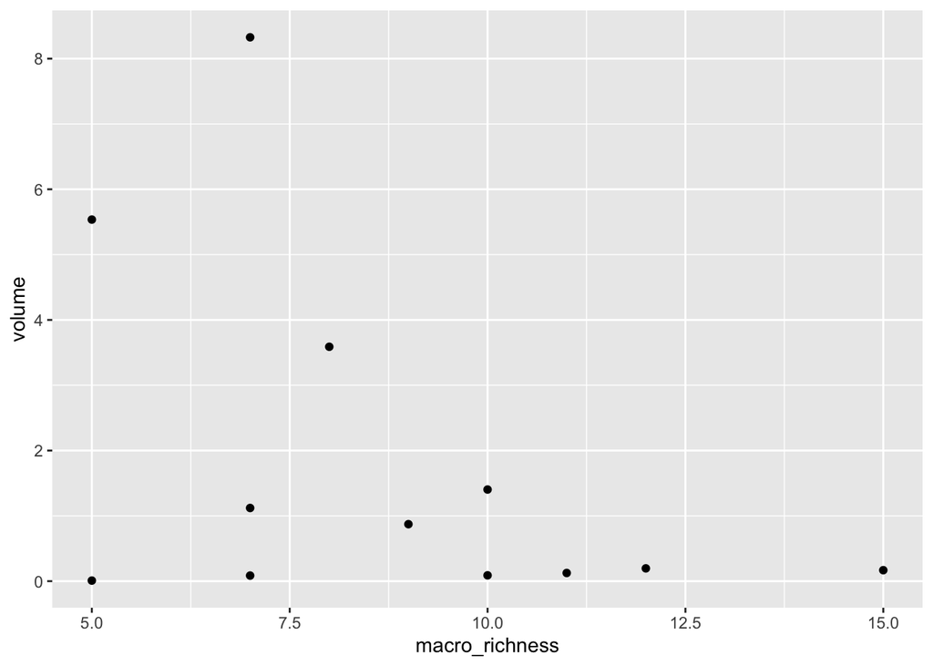

```r
ggplot(tide_pool_data, aes(x = macro_richness, y = volume)) +  # doesn't matter what order x/y is in
  geom_point()
```

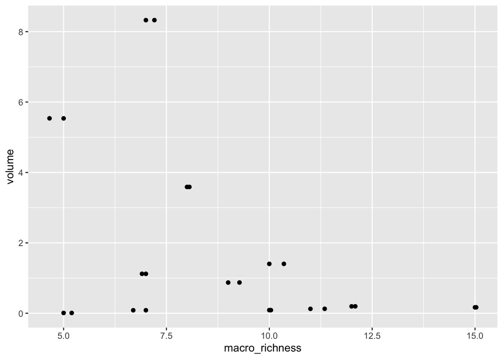

```r
ggplot(tide_pool_data, aes(x = macro_richness, y = volume)) +
  geom_point() +
  geom_jitter()   # student should add geom_jitter() call to second plot, better if comments to the code are added
```

**11b. Create a bar plot showing the macro richness by tidepool size.**

(HINT: you will need to use the argument `stat = 'identity'` in your `geom_` call).

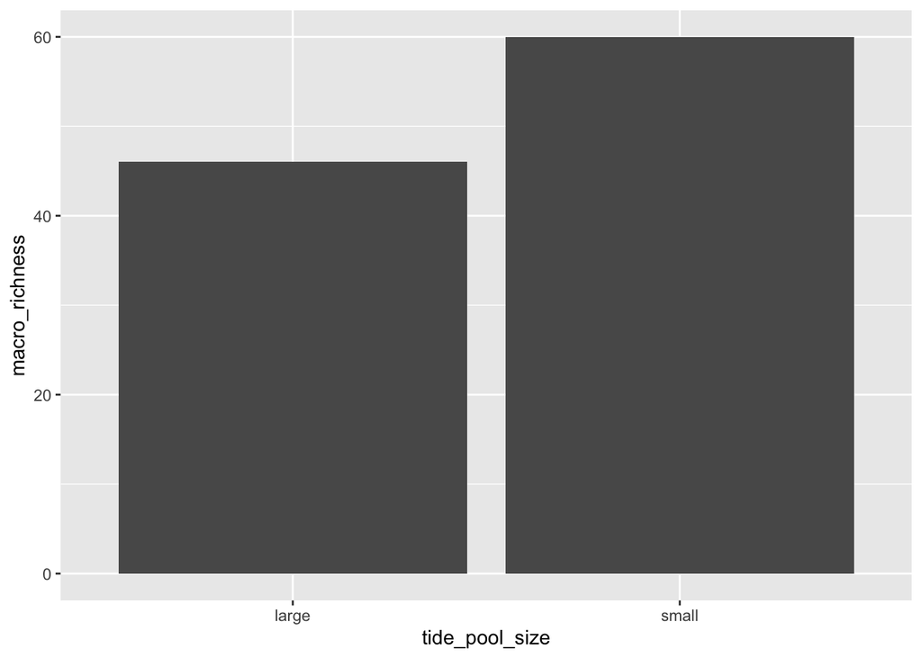

```r
ggplot(data = tide_pool_data, aes(x = tide_pool_size, y = macro_richness)) +
  geom_bar(stat = 'identity')
```

**11c. Use the** `?geom_bar` **help command to pull up the help page for the** `geom_bar()` **command. Spend a little bit of time reading. You can also look at** `?geom_col`.

```r
?geom_bar
?geom_col
```

**Why do we need to use the** `stat = 'identity'` **argument when running** `geom_bar()`?

Answer: It leaves the data as is, rather than simply counting the number of cases for the x axis.

**11d. What would happen if we don’t add stat = ‘identity’? Test it out in the console.**

Answer: The bar graph won’t run, given that stat_count() requires an x or y aesthetic. Can’t compute first layer.

## Question 12

**Using the tidepool metadata, create a scatter plot that shows the relationship between the sessile and mobile macro-organisms Shannon diversity colored by tidepool size.**

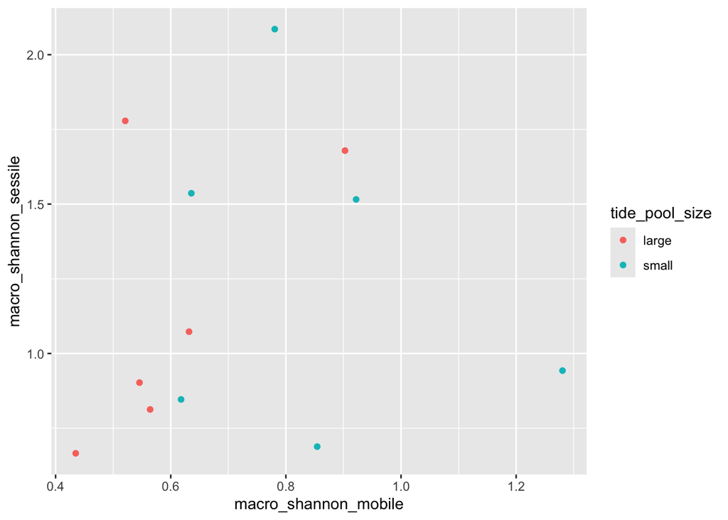

```r
ggplot(data = tide_pool_data, aes(x = macro_shannon_mobile, y = macro_shannon_sessile,
                                  color = tide_pool_size)) + # better is color layer is on seperate line
  geom_point()
```

## Question 13

**Using the penguins data set, create a scatter plot faceted by species and island that explores the relationship between bill depth and bill length. Add additional aesthetic mappings as wanted or needed.**

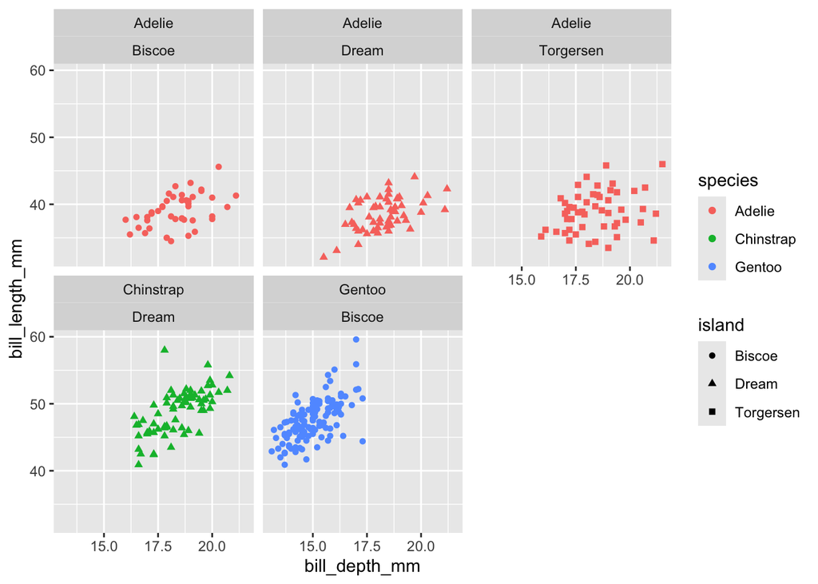

```r
ggplot(data = penguins, aes(x = bill_depth_mm, y = bill_length_mm,
                            color = species, shape = island)) + # optional, but HIGHLY reccomended
  geom_point() +
  facet_wrap(species ~ island)
```

## Question 14

**Using the penguins data set and a pipe string, create a scatter plot faceted by species and sex that explores the relationship between bill depth and body mass only in the year 2007.**

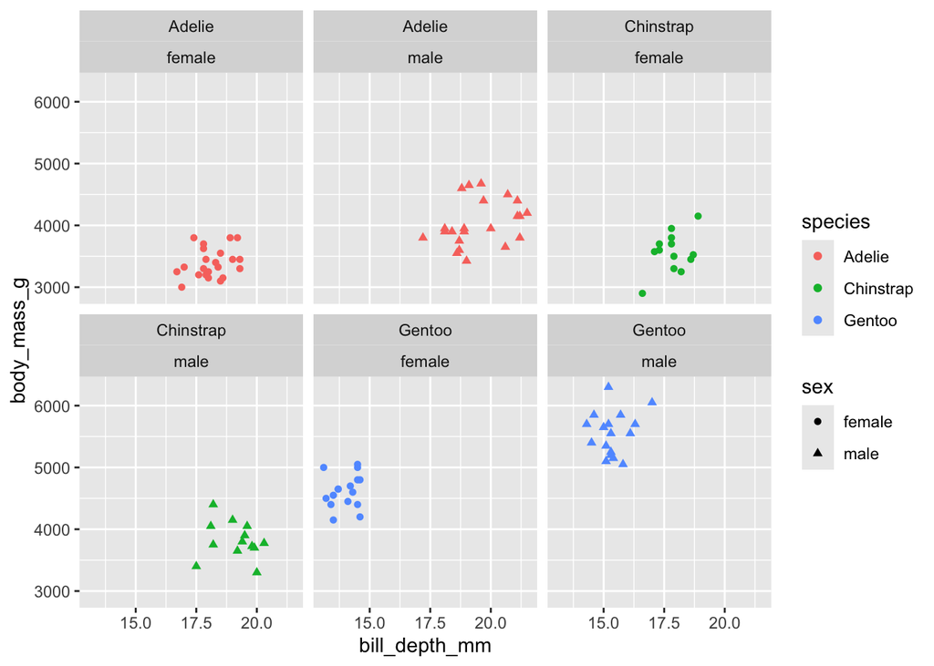

```r
penguins %>%
  drop_na() %>%                                       # this should be included!!!!!!!
  filter(year %in% c(2007)) %>%                       # can also be 'year == 2007'
  ggplot(aes(x = bill_depth_mm, y = body_mass_g,
             color = species, shape = sex)) +         # additional aesthetics encouraged
  geom_point() +
  facet_wrap(species ~ sex)                           # can be in either order
```

## Question 15

**Using the tidepool metadata, explore the relationship between macro organism richness and tide pool volume between the two tide pool sizes (large and small). Fit a linear regression line to visualize the linear relationship between y ~ x.**

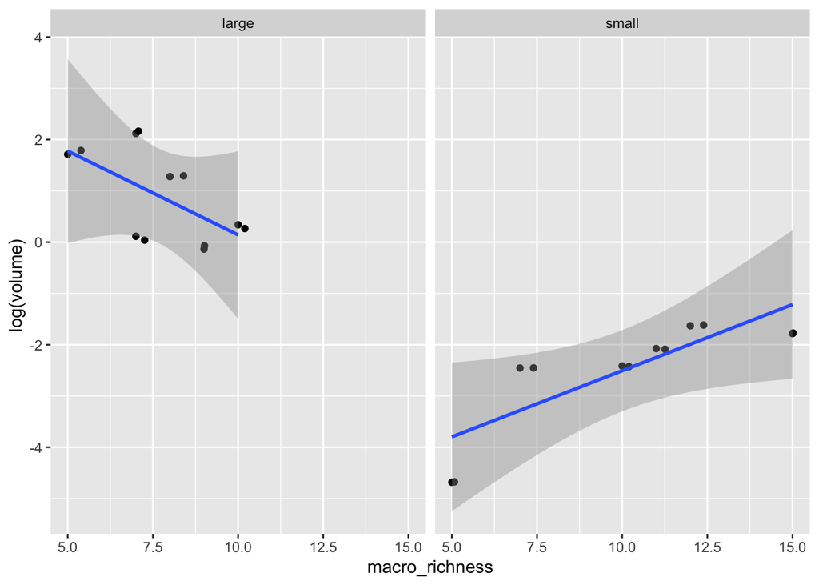

```r
ggplot(data = tide_pool_data, aes(x = macro_richness,
                                  y = log(volume))) +                # log should be on volume axis
  geom_point() +
  geom_jitter() +
  facet_wrap(~ tide_pool_size) +                                     # step needs to come BEFORE smooth
  geom_smooth(method = 'lm')                                         # can include se if wanted
```

*(HINT: Notice the slopes of your lines. How might you better visualize this? Figuring this one out might be tricky and will involve you using the mathematical operator log() on one of the axis. You can do so without piping using dplyr commands OR altering the data frame itself).*